# QTM 385 - Experimental Methods

## Assignment 06

# Instructions

As in previous assignments, here are 10 questions related to our recent classes. This time, they cover attrition. Please answer all question and export the file as a PDF or html file. If you use R or Jupyter Notebook, make sure to include both the code and the output in the document.

If you have any questions about the assignment, feel free to email me at

danilo.freire@emory.edu.

Good luck!

# Questions

1. Sometimes experimental researchers exclude subjects from their analysis because the subjects (1) appear to understand what hypothesis the experiment is testing, (2) seem not to be taking the experiment seriously, or (3) fail to follow directions. Discuss whether each of these three practices is likely to introduce bias when the researcher compares average outcomes among non-excluded subjects. (From Gerber & Green, 2012, p. 245)

Excluding subjects from an experiment based on their behavior or perceived understanding can introduce bias, depending on the exclusion criteria. If participants discern the hypothesis and change their behavior accordingly, their inclusion could introduce bias. However, excluding them could also lead to bias if those who understand the hypothesis differ systematically from those who do not. For example, more educated or attentive participants may be more likely to infer the hypothesis, meaning the remaining sample may be less representative of the general population. Similarly, removing participants who do not take the experiment seriously can be beneficial for internal validity, ensuring that the observed effects are due to the intervention rather than random responses. However, if the definition of "not serious" disproportionately removes certain types of participants, such as those with lower motivation or specific personality traits, the remaining sample may not reflect the broader population. This introduces selection bias, potentially overestimating the intervention’s effectiveness in real-world settings.

Participants who fail to follow directions may introduce noise into the data rather than systematic bias. However, excluding them can introduce bias if noncompliance correlates with characteristics relevant to the treatment effects. For example, if individuals with lower cognitive ability or attention spans are more likely to be removed, the remaining sample might not generalize well to populations that include such individuals. While exclusions can sometimes improve the quality of an experiment, they risk introducing selection bias if the remaining sample is systematically different from the intended population. A better approach might involve robustness checks, intention-to-treat analyses, or sensitivity analyses to assess how exclusions influence results.

1. Suppose a researcher studying a developing country plans to conduct an experiment to assess the effects of providing low-income households with cash grants if they agree to keep their children in school and take them for regular visits to health clinics. The primary outcome of interest is whether children in the treatment group are more likely to complete high school. A random sample of 1,000 households throughout the country is allocated to the treatment group (cash grants), and another sample of 1,000 households is allocated to the control group.

In this experiment, randomly assigning 1,000 households to receive cash grants with conditions related to school attendance and health checkups ensures that differences in high school completion rates between the treatment and control groups can be causally attributed to the intervention. Since the assignment is random, confounding variables—such as household income, parental education, or regional differences—should be evenly distributed across groups, reducing selection bias. However, challenges may arise if compliance varies; for example, some households in the treatment group might not fully adhere to the conditions, while others in the control group may independently seek similar support through other means. Such deviations could dilute the estimated treatment effect, making it necessary to conduct both intention-to-treat (ITT) and treatment-on-the-treated (TOT) analyses to better understand the impact.

Additionally, external and implementation factors may affect the validity of the study. If the cash grants create incentives that encourage certain behaviors only temporarily, the long-term sustainability of their effects remains uncertain. Moreover, spillover effects could occur if households in the control group are indirectly influenced by the intervention through community interactions. For instance, if treatment households share financial resources or information with control households, the difference in high school completion rates between groups might be underestimated. Ensuring proper monitoring and follow-up data collection will be crucial for interpreting the results accurately and assessing whether conditional cash transfers can be an effective and scalable policy tool for improving educational outcomes in developing countries.

1. Suppose that halfway through the project, a civil war breaks out in half of the country. Researchers are prevented from gathering outcomes for 500 treatment and 500 control subjects living in the war zone. What are the implications of this type of attrition for the analysis and interpretation of the experiment?

The outbreak of civil war and the resulting inability to collect data from 500 treatment and 500 control households introduce **attrition bias**, potentially undermining the experiment's validity. If the war-affected households differ systematically from those remaining in the study—for example, if they were already more vulnerable, faced greater economic hardship, or had lower baseline educational attainment—then the final sample may no longer be representative of the original population. This form of non-random attrition can bias the estimated treatment effects if the intervention's impact differs in war-affected areas compared to unaffected regions. Moreover, if the war disrupts education and health systems in ways that differentially impact treatment and control households, the comparability of the two groups is compromised. To address this issue, researchers may conduct robustness checks, compare baseline characteristics of retained and lost households, and explore methods such as inverse probability weighting to adjust for potential selection bias in the remaining sample.

1. Another identical experiment is performed in a different developing country. This time the attrition problem is as follows: households that were offered cash grants are more likely to live at the same address years later, when researchers return in order to measure outcomes. Of the 1,000 households assigned to the treatment group, 900 are found when researchers return to measure outcomes, as opposed to just 700 of the 1,000 households in the control group. What are the implications of this type of attrition for the analysis and interpretation of the experiment? (from Gerber & Green, 2012, p. 246)

This form of attrition, where households in the treatment group are more likely to remain in the study than those in the control group, introduces a potential source of bias that can affect the interpretation of the experiment’s results. If the households that remain in the sample differ systematically from those that cannot be located, the estimated treatment effects may be distorted. For example, if receiving cash grants increases household stability—perhaps by improving financial security, reducing migration, or lowering dropout rates due to economic pressures—then the treatment group may contain a higher proportion of households that were already more likely to support their children’s education. Meanwhile, the control group may be disproportionately composed of more transient, economically unstable households that faced greater barriers to school completion. This imbalance could lead to an overestimation of the program’s effectiveness if the observed treatment group is inherently different from the full original sample.

To address this issue, researchers should assess whether baseline characteristics differ between tracked and lost households in both groups. If systematic differences exist, statistical methods such as inverse probability weighting or bounding approaches may help correct for potential bias. Additionally, researchers should consider whether the observed treatment effects would hold in a scenario where attrition was evenly distributed. If treatment effects are driven in part by increased household stability rather than the cash transfer itself, policymakers should take this into account when designing and interpreting similar programs in other contexts.

1. In the RAND Health Insurance Experiment (HIE), attrition varied significantly across the different insurance plans (free vs. cost-sharing). Discuss how differential attrition rates across treatment subgroups can lead to misleading conclusions about the average treatment effect (ATE), even if overall attrition appears modest. How does this relate to the concept of $MIPO|X$? How can this be tested?

Differential attrition across treatment subgroups in the RAND Health Insurance Experiment (HIE) can lead to misleading conclusions about the average treatment effect (ATE) because the remaining sample may no longer be representative of the original randomized groups. If individuals in cost-sharing plans were more likely to drop out due to financial strain or dissatisfaction, while those in free insurance plans remained, the observed outcomes would disproportionately reflect a subset of the original population with systematically different characteristics. This can create bias in the estimated ATE if the probability of being observed is correlated with potential health outcomes. This issue relates to the concept of *Missing at Random given X* (MIPO|X), which assumes that, conditional on observed covariates, missingness is not systematically related to unobserved outcomes. To test for potential attrition bias, researchers can compare baseline characteristics of those who remain versus those lost across treatment groups. Additionally, bounding techniques, inverse probability weighting, or sensitivity analyses can help assess how much the results depend on selective attrition and whether the estimated treatment effects remain robust under different assumptions.

1. Explain why relying solely on Inverse Probability Weighting (IPW) to adjust for attrition can be problematic. What assumptions are required for IPW to produce unbiased estimates? What are the consequences if these assumptions are violated? Is it better to present the estimate with and without IPW? Justify your answers with further readings Gerber & Green (2012, p. 244) has some suggested readings that you can use.

Relying solely on Inverse Probability Weighting (IPW) to adjust for attrition can be problematic because it assumes that missingness is entirely explained by observed covariates, meaning that, conditional on these covariates, the probability of attrition is unrelated to unobserved outcomes. This assumption, known as *Missing at Random (MAR)*, is strong and often unrealistic in real-world experiments where unobserved factors, such as motivation or health status, may influence both attrition and outcomes. If this assumption is violated, IPW can still produce biased estimates, particularly if the weights amplify noise by giving excessive influence to a small number of heavily weighted observations. Additionally, if the estimated probabilities of remaining in the study are very small for some individuals, the resulting weights may be highly variable, leading to unstable or inefficient estimates. To account for these potential issues, it is generally advisable to present estimates both with and without IPW to assess the sensitivity of the results. Researchers may also use other methods, such as bounding techniques (e.g., Lee bounds) or sensitivity analyses, to gauge the robustness of findings under different assumptions about the missing data mechanism. Gerber & Green (2012) suggest further readings such as Manski (1995) and Little & Rubin (2002), which discuss the limitations of IPW and alternative approaches to handling attrition bias.

1. Building on the idea of minimising attrition during an experiment, propose three specific and practical data collection strategies (beyond simply “collect more data”) that might help reduce attrition in a longitudinal study. Justify why these strategies might be effective.

To minimize attrition in a longitudinal study, researchers can implement strategies that enhance participant engagement, reduce logistical barriers, and maintain contact over time. First, providing incentives tailored to participants’ needs—such as small cash payments, mobile phone credits, or transportation reimbursements—can encourage continued participation by offsetting costs or inconveniences associated with follow-ups. Second, maintaining regular and personalized communication, such as periodic check-ins through phone calls, text messages, or community visits, helps build trust and reminds participants of their commitment to the study. Personalized interactions can also signal the study’s importance, increasing retention. Third, using multiple and flexible follow-up methods—such as home visits, phone surveys, and online data collection—ensures that participants who relocate or face unexpected life disruptions can still be reached. This multimodal approach reduces the likelihood of losing participants due to mobility, accessibility, or other constraints. By addressing financial, psychological, and logistical barriers, these strategies can help sustain participant involvement and improve the study’s validity by reducing differential attrition.

1. How is the validity of IPW estimates dependent on the assumption of MIPO|X? Discuss what happens if this assumption is violated.

The validity of Inverse Probability Weighting (IPW) estimates relies on the assumption of *Missing at Random given X* (MIPO|X), which means that, conditional on observed covariates, the probability of missingness is independent of the unobserved potential outcomes. If this assumption holds, IPW can correct for attrition by reweighting the observed sample to resemble the full population, ensuring unbiased estimates. However, if this assumption is violated—meaning that missingness is correlated with unobserved factors affecting the outcome—IPW will fail to fully correct for selection bias. For example, if participants with worse health outcomes are more likely to drop out regardless of their observable characteristics, then weighting the remaining participants cannot account for this unmeasured difference, leading to biased treatment effect estimates. In such cases, sensitivity analyses, bounding methods, or alternative modeling approaches, such as selection models, may be needed to assess the extent of bias and explore how results change under different assumptions about the missing data mechanism.

1. For the upcoming questions, you will be using a dataset called [attrition_data.csv, which is available in the course repository](https://github.com/danilofreire/qtm385/blob/main/assignments/06-assignment/attrition_data.csv). This contains the results from an experiment with attrition in both the covariates and the treatment. There are two outcome variables in the dataset. Using the `attritevis` package, as shown in class, please answer do the following:

Load the dataset and show the number of cases of attrition and their proportion. Estimate the balance across attrition for `outcome2`. What do you observe?

```python
import pandas as pd
import numpy as np
df = pd.read_csv("attrition_data.csv")
print(df.head())
```

```
    age   sex  education  state  income religion  attrition_2  cards_a  \
0  36.0  male        7.0   33.0     2.0       10          3.0      0.0
1  35.0  male        8.0   46.0     4.0        2          2.0      0.0
2  29.0  male        7.0   49.0     2.0        1          3.0      0.0
3  42.0  male        9.0   33.0     4.0        9          2.0      1.0
4  45.0  male        7.0    9.0     2.0        2          1.0      1.0

   treatment  mood  outcome1  outcome2
0  treatment   NaN       NaN       NaN
1  treatment   5.0       0.0       5.0
2  treatment   4.0       0.0       5.0
3    control   3.0       0.0       3.0
4    control   4.0       0.0       4.0
```

```python
# 1. Show the number of attrition cases and their proportion
attrition_counts = df["attrition_2"].value_counts()
attrition_proportion = df["attrition_2"].value_counts(normalize=True)

# Display attrition summary
attrition_summary = pd.DataFrame({
    "Attrition Count": attrition_counts,
    "Proportion": attrition_proportion
})
print("Attrition Summary:")
print(attrition_summary)

# 2. Estimate the balance across attrition for `outcome2`
outcome2_balance = df.groupby("attrition_2")["outcome2"].mean()

# Display balance across attrition for outcome2
outcome2_balance_df = outcome2_balance.reset_index()
outcome2_balance_df.columns = ["Attrition Level", "Mean Outcome2"]

print("\nOutcome2 Balance Across Attrition Levels:")
print(outcome2_balance_df)
```

```
Attrition Summary:
     Attrition Count  Proportion
2.0              611    0.309681
3.0              468    0.237202
1.0              365    0.184997
4.0              294    0.149012
5.0              235    0.119108

Outcome2 Balance Across Attrition Levels:
   Attrition Level  Mean Outcome2
0              1.0       3.909091
1              2.0       3.621832
2              3.0       2.886889
3              4.0       3.029661
4              5.0       2.899497
```

1. Plot the attrition timeline with the total and the control and treatment groups. Use the parameters `y`, `treatment_q` and `outcome_q` to show the results. What do you observe?

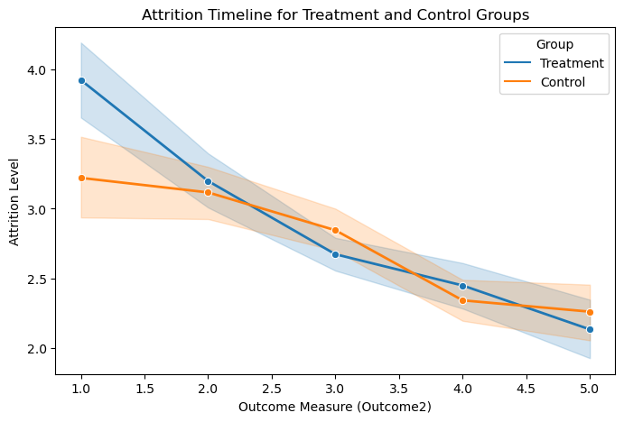

```python
import matplotlib.pyplot as plt
import seaborn as sns

# Define parameters
y = "attrition_2"     # Attrition levels
treatment_q = "treatment"  # Treatment assignment
outcome_q = "outcome2"  # Outcome variable

# Convert treatment column to categorical variable
df["treatment_group"] = df[treatment_q].map({"treatment": "Treatment", "control": "Control"})

# Plot the attrition timeline
plt.figure(figsize=(8, 5))
sns.lineplot(data=df, x=outcome_q, y=y, hue="treatment_group", marker="o", linewidth=2)

# Add labels and title
plt.xlabel("Outcome Measure (Outcome2)")
plt.ylabel("Attrition Level")
plt.title("Attrition Timeline for Treatment and Control Groups")
plt.legend(title="Group")

# Show plot
plt.show()
```

1. Estimate Manski bounds for the outcomes. Interpret the results.

```python
# Step 1: Identify treatment and control groups
treatment_group = df[df["treatment"] == "treatment"]
control_group = df[df["treatment"] == "control"]

# Step 2: Compute observed means (ignoring missing values)
observed_treatment_mean = treatment_group["outcome2"].mean(skipna=True)
observed_control_mean = control_group["outcome2"].mean(skipna=True)

# Step 3: Define worst and best possible values for outcome2
worst_outcome = df["outcome2"].min(skipna=True)  # Worst case scenario
best_outcome = df["outcome2"].max(skipna=True)   # Best case scenario

# Step 4: Compute Manski Bounds

# Lower Bound: Assign worst outcome to missing values
lower_bound_treatment = (treatment_group["outcome2"].sum(skipna=True) + worst_outcome * treatment_group["outcome2"].isna().sum()) / len(treatment_group)
lower_bound_control = (control_group["outcome2"].sum(skipna=True) + worst_outcome * control_group["outcome2"].isna().sum()) / len(control_group)
lower_bound_effect = lower_bound_treatment - lower_bound_control

# Upper Bound: Assign best outcome to missing values
upper_bound_treatment = (treatment_group["outcome2"].sum(skipna=True) + best_outcome * treatment_group["outcome2"].isna().sum()) / len(treatment_group)
upper_bound_control = (control_group["outcome2"].sum(skipna=True) + best_outcome * control_group["outcome2"].isna().sum()) / len(control_group)
upper_bound_effect = upper_bound_treatment - upper_bound_control

# Step 5: Display Results
manski_bounds_df = pd.DataFrame({
    "Group": ["Treatment", "Control"],
    "Observed Mean": [observed_treatment_mean, observed_control_mean],
    "Lower Bound (Worst Case)": [lower_bound_treatment, lower_bound_control],
    "Upper Bound (Best Case)": [upper_bound_treatment, upper_bound_control]
})

effect_bounds_df = pd.DataFrame({
    "Effect Type": ["Lower Bound", "Upper Bound"],
    "Treatment Effect Estimate": [lower_bound_effect, upper_bound_effect]
})

# Print results
print("Manski Bounds Estimates:")
print(manski_bounds_df)

print("\nManski Bounds for Treatment Effect:")
print(effect_bounds_df)
```

```
Manski Bounds Estimates:
       Group  Observed Mean  Lower Bound (Worst Case)  Upper Bound (Best Case)
0  Treatment       3.350000                  3.088889                 3.533333
1    Control       3.332574                  3.122280                 3.482902

Manski Bounds for Treatment Effect:
   Effect Type  Treatment Effect Estimate
0  Lower Bound                  -0.033391
1  Upper Bound                   0.050432
```

1. Finally, estimate Lee bounds and contrast the result with the previous two. Which of the two methods would you use? Justify your answer and elaborate on the possible violation of the monotonicity assumption.

```python
def compute_lee_bounds(df, treatment_col, outcome_col, attrition_col):
    """
    Computes Lee Bounds for estimating treatment effect while accounting for attrition.

    Parameters:
    df (DataFrame): Dataset with treatment, outcome, and attrition variables.
    treatment_col (str): Column indicating treatment assignment.
    outcome_col (str): Outcome variable column.
    attrition_col (str): Attrition indicator column.

    Returns:
    lee_bounds_df (DataFrame): DataFrame with lower and upper Lee bound estimates.
    """
    # Step 1: Identify treatment and control groups
    treatment_group = df[df[treatment_col] == "treatment"]
    control_group = df[df[treatment_col] == "control"]

    # Step 2: Compute attrition rates
    attrition_rate_treatment = treatment_group[attrition_col].isna().mean()
    attrition_rate_control = control_group[attrition_col].isna().mean()

    # Step 3: Compute trimming proportion (use the group with the **lower attrition rate**)
    trim_prop = min(attrition_rate_treatment, attrition_rate_control)

    # Step 4: Trim the group with **higher retention** by removing observations with highest/lowest outcomes
    def trim_group(group, outcome_col, trim_prop):
        group_sorted = group.sort_values(by=outcome_col, ascending=True)
        n_trim = int(np.floor(len(group_sorted) * trim_prop))
        return group_sorted.iloc[n_trim:-n_trim] if n_trim > 0 else group_sorted

    if attrition_rate_treatment > attrition_rate_control:
        trimmed_treatment = trim_group(treatment_group, outcome_col, trim_prop)
        trimmed_control = control_group
    else:
        trimmed_treatment = treatment_group
        trimmed_control = trim_group(control_group, outcome_col, trim_prop)

    # Step 5: Compute Lee Bounds
    lower_bound_effect = trimmed_treatment[outcome_col].mean() - trimmed_control[outcome_col].mean()
    upper_bound_effect = treatment_group[outcome_col].mean(skipna=True) - control_group[outcome_col].mean(skipna=True)

    # Step 6: Store results in DataFrame
    lee_bounds_df = pd.DataFrame({
        "Bound Type": ["Lower Lee Bound", "Upper Lee Bound"],
        "Treatment Effect Estimate": [lower_bound_effect, upper_bound_effect]
    })

    return lee_bounds_df

# Apply Lee Bounds computation
lee_bounds_df = compute_lee_bounds(df, treatment_col="treatment", outcome_col="outcome2", attrition_col="outcome2")

# Print Results
print("Lee Bounds Estimates:")
print(lee_bounds_df)
```

```
Lee Bounds Estimates:
        Bound Type  Treatment Effect Estimate
0  Lower Lee Bound                   0.241835
1  Upper Lee Bound                   0.017426
```